# Protein-level t-SNE on TM-score distance, colored by diet

`case_study.Rmd` visualizes diet structure with PCoA on the abundance-weighted *sample* distance. This report goes one level down, to the proteins themselves: every protein in the diet study, placed by t-SNE on its pairwise TM-score distance (`1 - cosine(TM-Vec1)`, the same ground metric `rollupStructural()` clusters on), colored by the diet where it is most abundant. The question is purely visual – does TM-Vec’s structural geometry carry any visible relationship to diet – not a hypothesis test.

```r
Sys.setenv(KMP_DUPLICATE_LIB_OK = "TRUE")

library(phyloseq)
library(ggplot2)
library(here)
for (f in list.files("R", full.names = TRUE)) source(f)

path <- here("data", "test_study")
```

## Data and rarefaction

Same table, same rarefaction as `case_study.Rmd`, reproduced here rather than sourced so this report renders standalone.

```r
ps <- readRDS(file.path(path, "ps.rds"))
floor_depth <- min(sample_sums(ps))

set.seed(1)
psd <- rarefy_even_depth(ps, sample.size = floor_depth, rngseed = 1,
                         replace = FALSE, verbose = FALSE)
psd <- prune_samples(sample_data(psd)$phase != "baseline", psd)
psd <- prune_taxa(taxa_sums(psd) > 0, psd)
sample_data(psd)$diet <- factor(sample_data(psd)$diet)
psd
```

```
## phyloseq-class experiment-level object
## otu_table()   OTU Table:         [ 19192 taxa and 99 samples ]
## sample_data() Sample Data:       [ 99 samples by 9 sample variables ]
## tax_table()   Taxonomy Table:    [ 19192 taxa by 8 taxonomic ranks ]
## refseq()      AAStringSet:      [ 19192 reference sequences ]
```

## Embedding

TM-Vec1, reusing the cache `case_study.Rmd` already built – every one of the 19192 proteins here was embedded there, so this just reads the file rather than re-running `embed_proteins()`.

```r
Zall <- readRDS(file.path(path, "embeddings_tmvec1.rds"))
stopifnot(all(taxa_names(psd) %in% rownames(Zall)))
Z <- Zall[taxa_names(psd), ]
```

## Dominant diet per protein

Proteins don’t have a diet – samples do. Each protein is assigned the diet whose samples carry its highest mean count: the same “mean count by diet” comparison in `case_study.Rmd`’s top-bin table, just run over every protein instead of one bin’s members. A protein seen in a handful of samples “belongs” to whichever diet those samples happen to be, so this describes where mass sits, not a claim that every protein is diet-specific.

```r
cnt <- t(as(otu_table(psd), "matrix"))     # samples in rows
md  <- data.frame(sample_data(psd))

diet_mean <- sapply(levels(md$diet), function(d) colMeans(cnt[md$diet == d, , drop = FALSE]))
dominant_diet <- factor(colnames(diet_mean)[max.col(diet_mean, ties.method = "first")],
                        levels = levels(md$diet))
names(dominant_diet) <- rownames(diet_mean)
table(dominant_diet)
```

```
## dominant_diet
## Casein    Egg    Pea   Rice    Soy  Yeast
##   3931   2686   3024   2671   5157   1723
```

## t-SNE on TM-score distance

All 19192 proteins fit in one run: the full pairwise cosine-distance matrix plus the t-SNE fit together take about four minutes on a laptop, so the 10%-subsample fallback wasn’t needed.

```r
D <- proxy::dist(Z, method = "cosine")   # 1 - cosine similarity == 1 - predicted TM-score

set.seed(1)
ts <- Rtsne::Rtsne(D, is_distance = TRUE, perplexity = 30, verbose = FALSE)
```

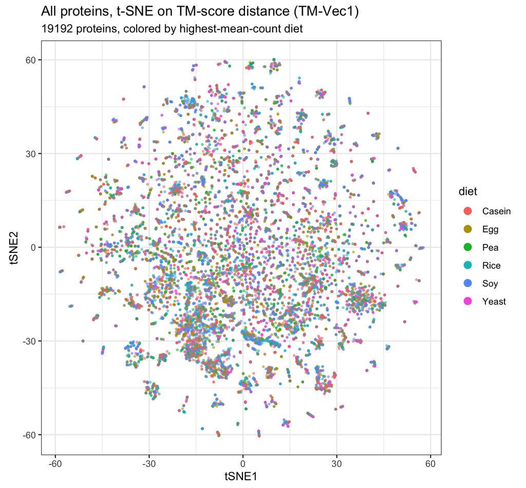

```r
df <- data.frame(ts$Y, diet = dominant_diet[taxa_names(psd)])
names(df)[1:2] <- c("tSNE1", "tSNE2")

ggplot(df, aes(tSNE1, tSNE2, color = diet)) +
  geom_point(size = 0.6, alpha = 0.5) +
  labs(title = "All proteins, t-SNE on TM-score distance (TM-Vec1)",
       subtitle = paste0(ntaxa(psd), " proteins, colored by highest-mean-count diet")) +
  guides(color = guide_legend(override.aes = list(size = 3, alpha = 1))) +
  theme_bw() + coord_equal()
```

## Conclusion

The plot resolves into many small, tight islands – the same structural bins `rollupStructural()` finds by construction, since t-SNE on this same distance is just a non-linear view of that clustering. Diet colors are thoroughly mixed within every island: no visible diet structure at the protein level, in either the islands or the space between them.

That is the expected answer, not a null result to explain away. A protein’s *structure* has no reason to depend on which diet’s samples happened to carry more of it – diet signal in this dataset lives in **which proteins are abundant where** (the sample-level weighted UniFrac-style distances in `case_study.Rmd`), not in the structural identity of the proteins themselves. This report is the negative control that claim implicitly depends on: if diet colors *had* separated here, it would mean TM-Vec’s geometry was secretly encoding diet (e.g., via amino-acid composition correlated with protein source), which would undercut treating structure and abundance as separate axes. It doesn’t, so they aren’t.